# Рисунки для статьи

## Динамика паразитемии

```r
finch_il_2 <- finch_il %>% filter(Experiment != "Control")

M1_Par_gam <- gam(Parasitemia ~ s(DPI) + Experiment  + s(Ring, k = 53, bs = "re"),  method = "REML", data = finch_il_2, family = "nb")

M2_Par_gam <- gam(Parasitemia ~ s(DPI, by = Experiment) + Experiment  + s(Ring, k = 53, bs = "re"),  method = "REML", data = finch_il_2, family = "nb")
```

```r
AIC(M1_Par_gam, M2_Par_gam)
```

```
##                  df      AIC
## M1_Par_gam 38.53825 1362.628
## M2_Par_gam 43.91247 1326.444
```

Проверка валидности

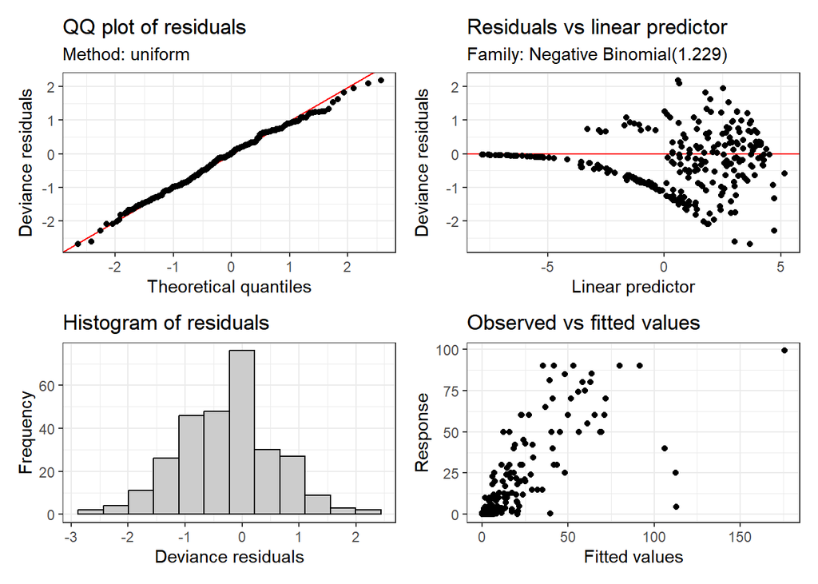

Table ++. GAM parameters characterizing the course of parasetemia after parasite inoculation.

Parametric terms

| term | estimate | std.error | statistic | p.value |
| --- | --- | --- | --- | --- |
| (Intercept) | 0.2603116 | 0.3645873 | 0.7139897 | 0.4752336 |
| ExperimentGRW2 | -0.2207647 | 0.5639016 | -0.3914951 | 0.6954313 |

smoothers

| term | edf | ref.df | statistic | p.value |
| --- | --- | --- | --- | --- |
| s(DPI):ExperimentSGS1 | 6.938614 | 7.850353 | 234.9969 | 0 |
| s(DPI):ExperimentGRW2 | 6.286396 | 7.310971 | 119.5584 | 0 |
| s(Ring) | 25.379038 | 38.000000 | 109.3947 | 0 |

Визуализация модели

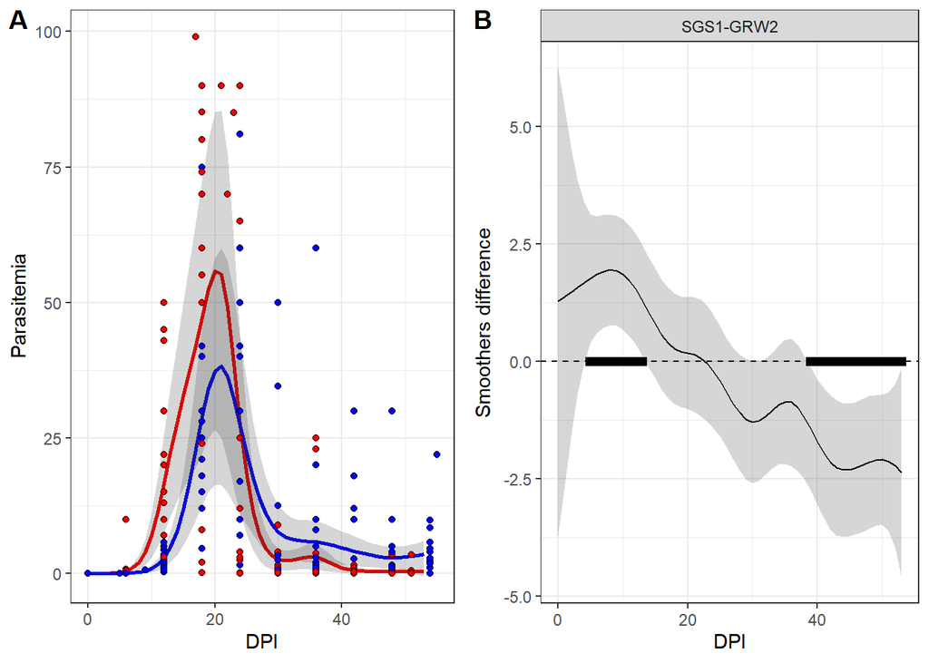

Figure +. Parasitemia at different days after inoculation (DPI) in two Plasmodium species. Panel A represents the observed number of merozoites (dots) and predicted GAM (lines, gray areas around the lines represent 95% CI). Panel B represents the difference between smoothers. Time periods when the difference between smoothers is significantly different from zero are marked by black rectangles.

## Динамика RMR на фоне развития заболевания

```r
M1_RMR_gam <- gam(log10(RMR) ~ s(DPI) + Experiment + log10(Mass)  + s(Ring, k = 53, bs = "re"),  method = "REML", data = finch_reduced)


M2_RMR_gam <- gam(log10(RMR) ~ s(DPI, by = Experiment) + Experiment + log10(Mass)  + s(Ring, k = 53, bs = "re"),  method = "REML", data = finch_reduced)
```

```r
AIC(M1_RMR_gam, M2_RMR_gam)
```

```
##                  df      AIC
## M1_RMR_gam 33.18439 -700.048
## M2_RMR_gam 52.63803 -753.076
```

Будем рассматривать модель №2.

Проверка ее валидности

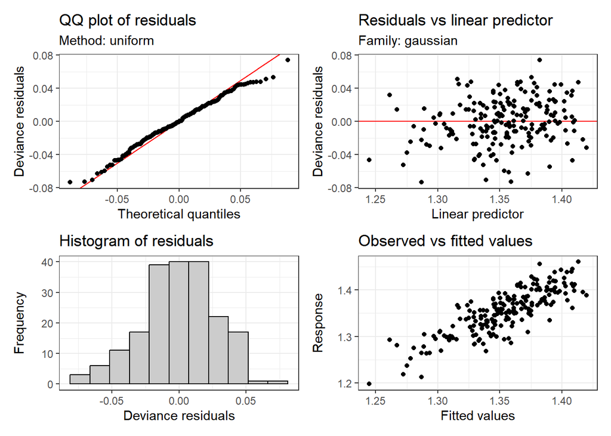

### Описание модели

Table +++. GAM parameters characterizing the course of RMR after parasite inoculation.

Parametric terms “Control” was taken as reference level for the factor “Group”

| term | estimate | std.error | statistic | p.value |
| --- | --- | --- | --- | --- |
| (Intercept) | 0.8667586 | 0.1083407 | 8.000302 | 0.0000000 |
| ExperimentSGS1 | -0.0210262 | 0.0107747 | -1.951444 | 0.0528774 |
| ExperimentGRW2 | 0.0069930 | 0.0110084 | 0.635240 | 0.5262450 |
| log10(Mass) | 0.4463987 | 0.0974461 | 4.580982 | 0.0000097 |

Smoothers

| term | edf | ref.df | statistic | p.value |
| --- | --- | --- | --- | --- |
| s(DPI):ExperimentControl | 3.353317 | 3.995504 | 3.050404 | 0.0188474 |
| s(DPI):ExperimentSGS1 | 3.478809 | 4.126216 | 12.958613 | 0.0000000 |
| s(DPI):ExperimentGRW2 | 4.745876 | 5.501000 | 5.796103 | 0.0000566 |
| s(Ring) | 32.230936 | 50.000000 | 2.134290 | 0.0000000 |

### Визуализации модели

### Попарное сравнение смузеров.

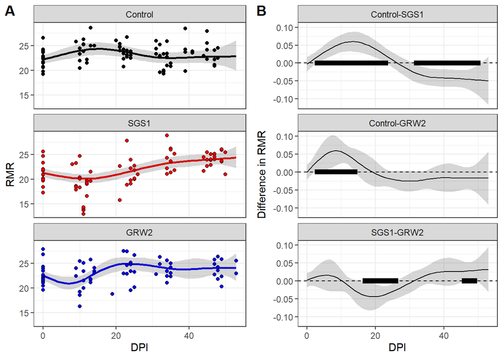

Figure +. RMR at different days after inoculation (DPI) in different birds’ groups. Panel A represents the observed RMR level (dots) and GAM predictions (lines and 95% CI). Panel B represents the difference between smoothers. Time periods when the difference between smoothers is significantly different from zero are marked by black rectangles.

## Динамика интрелейкина

```r
M1_IL_gam <- gam(log10(IL6_pg_ml) ~ s(DPI, k = 5) + Experiment  + s(Ring, k = 53, bs = "re"),  method = "REML", data = finch_il)

M2_IL_gam <- gam(log10(IL6_pg_ml) ~ s(DPI, by = Experiment, k = 5) + Experiment  + s(Ring, k = 53, bs = "re"),  method = "REML", data = finch_il)
```

```r
AIC(M1_IL_gam, M2_IL_gam)
```

```
##                 df       AIC
## M1_IL_gam 29.21474 -251.0863
## M2_IL_gam 42.32431 -353.2500
```

Аналогично, оптимальной будет модель с разными смузерами для каждой из групп.

Вот проверка ее валидности

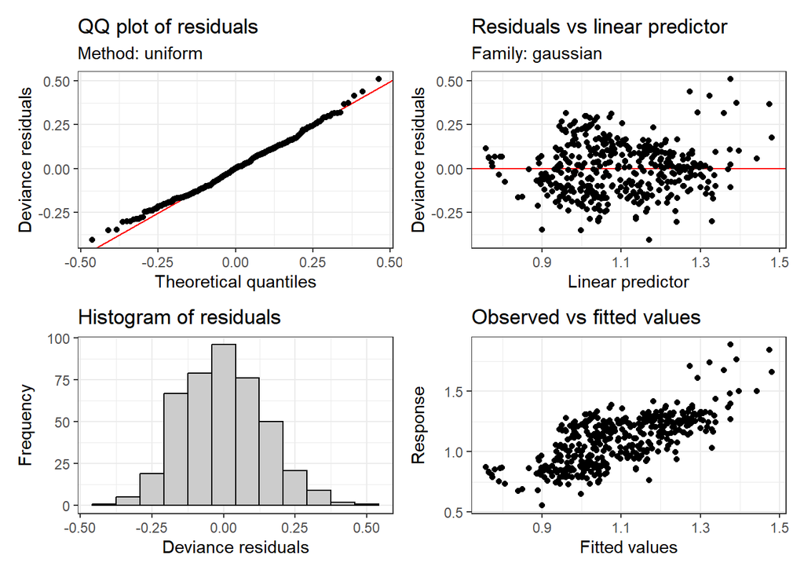

Table +++. GAM parameters characterizing the course of IL-6 concentration after parasite inoculation.

Parametric terms. “Control” was taken as reference level for the factor “Group”

| term | estimate | std.error | statistic | p.value |
| --- | --- | --- | --- | --- |
| (Intercept) | 1.1024811 | 0.0178942 | 61.610973 | 0.0000000 |
| ExperimentSGS1 | 0.0290625 | 0.0254962 | 1.139876 | 0.2550437 |
| ExperimentGRW2 | -0.0806343 | 0.0258581 | -3.118332 | 0.0019550 |

Smoothers

| term | edf | ref.df | statistic | p.value |
| --- | --- | --- | --- | --- |
| s(DPI):ExperimentControl | 3.835704 | 3.981939 | 25.1384067 | 0.00e+00 |
| s(DPI):ExperimentSGS1 | 3.479888 | 3.835300 | 23.9773201 | 0.00e+00 |
| s(DPI):ExperimentGRW2 | 3.900352 | 3.993298 | 15.0194797 | 0.00e+00 |
| s(Ring) | 25.264011 | 57.000000 | 0.9289817 | 4.56e-05 |

Визуализация этой модели

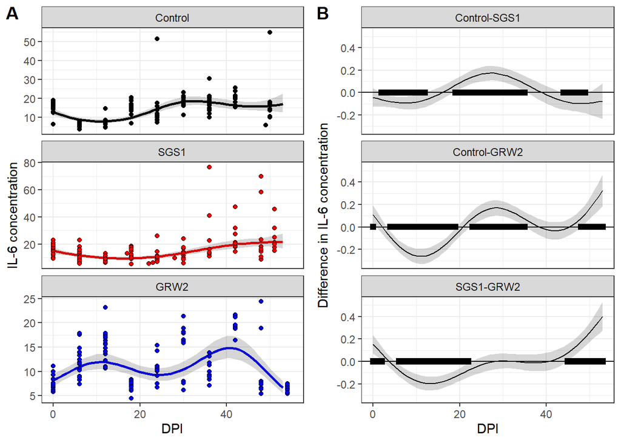

Figure +. IL-6 at different days after inoculation (DPI) in different birds’ groups. Panel A represents the observed IL-6 concentration (dots) and GAM predictions (lines and 95% CI). Panel B represents the difference between smoothers. Time periods when the difference between smoothers is significantly different from zero are marked by black rectangles.